# 金属製梁の設計。ウェブ剪断抵抗（非座屈）型。

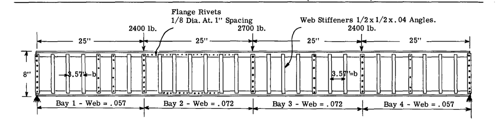

梁の概略図

## C10.15 例題。梁の強度検討。

図 C10.14 は、単純支持され、設計荷重として図に示すように3つの集中荷重を受ける組立て（I）断面梁を示している。

### 梁の曲げ強度の検討

梁の断面積は一定であるため、危険断面は曲げモーメントが最大となる梁の中央点である。

$$M_{\text{max}} = 3750 \times 50 - 2400 \times 25 = 127500 \text{ in.lb.}$$

図 C10.14 に示されるように、梁は外板にリベット接合されている。与えられた荷重下で圧縮状態にある上フランジでは、外板の特定の有効幅が梁のフランジとともに機能する。この有効外板幅は梁のフランジ応力に依存するが、これはまだ不明である。予備的な値として、各リベット線に対して $30t$ に等しい外板幅が機能していると仮定することは妥当である。引張側または下側では、外板全体が有効であり、梁の各側へ 2 インチ（各側の最初の外板縦通材への半分の距離）が有効となる。

図 C10.15 は、梁の中央スパンにおける有効断面の詳細を示している。引張フランジには3つのリベット穴があると仮定する。表 C10.4 は、最初に中心線基準軸に関する断面特性の計算を示し、次に中立軸へ変換した結果を示している。

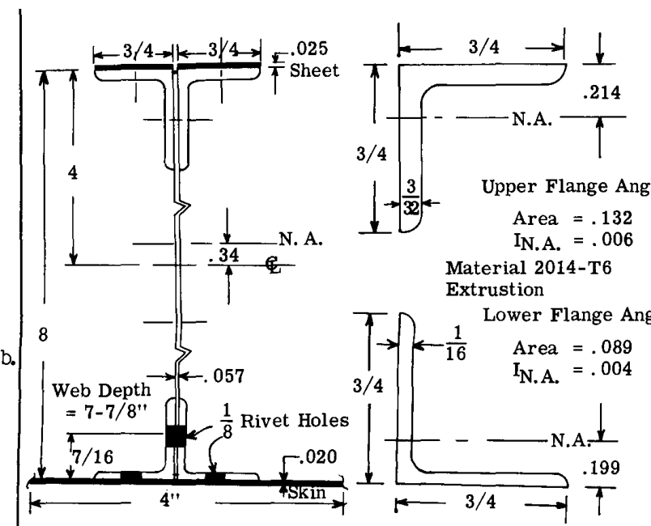

有効断面の詳細

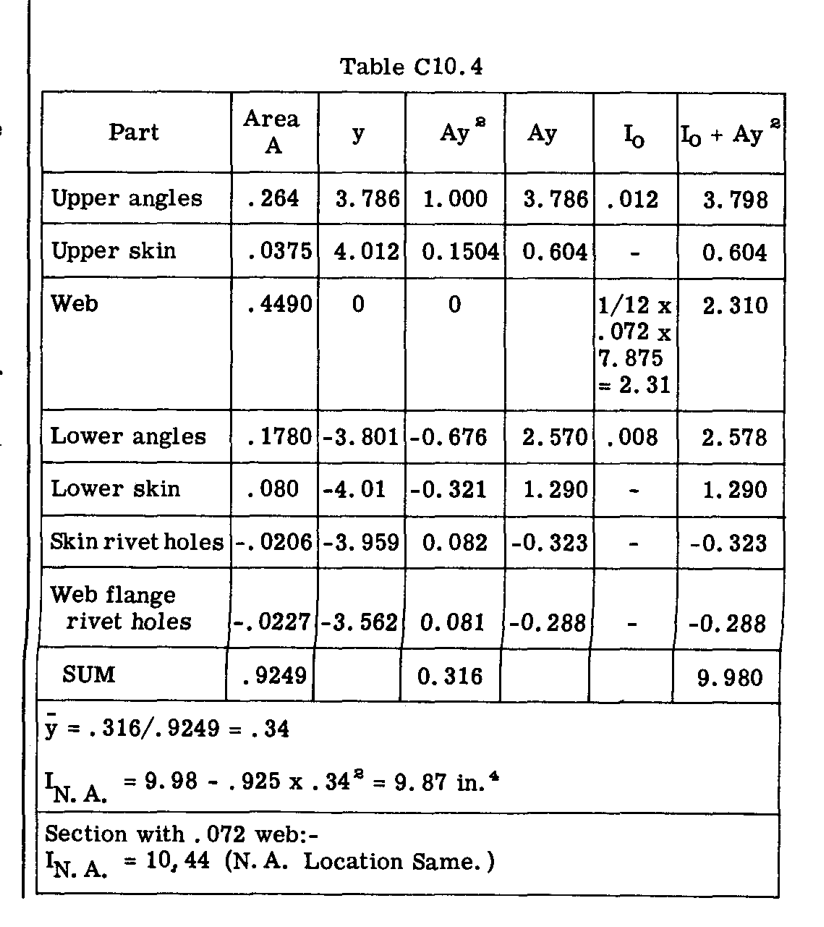

断面特性の計算表

上フランジのアングルの水平脚の中央点における曲げ応力: $I_{\text{N.A.}} = 10.44$

$$f_b = \frac{MY}{I} = \frac{127500 \times 3.614}{10.44} = 44200 \text{ psi}$$

外板の有効幅 $w$ として $30t = 0.75$ インチと仮定したことの検証を行う。第C7章より、

$$w = 1.9t \sqrt{\frac{E}{F_{ST}}}$$

ここで、 $F_{ST}$ はフランジ圧縮応力であり、 $44200 \text{ psi}$ である。したがって、

$$w = 1.90 \times 0.025 \sqrt{\frac{10,700,000}{44,200}} = 0.74 \text{ in.}$$

$w$ に対して $30t$ または $0.75$ インチを仮定していたため、誤差は非常に小さく、修正は不要である。

### フランジの許容圧壊圧縮応力の計算

フランジは外板とウェブによって互いに直交する二方向に支持されているため、柱としての挙動は防止され、許容応力はフランジ単体の圧壊（クリップリング）応力となる。

第C7章には圧壊応力の計算方法が記載されている。この例題ではNeedham（ニーダム）法を使用し、単一アングルの圧壊応力を計算する。

$$\frac{b'}{t} = \frac{0.75 - 3/64}{3/32} = 7.55$$

第C7章の図 C7.5 より、以下を得る。

$$\frac{F_{cs}}{\sqrt{F_{cy} E_c}} = 0.068$$

2014-T6 押出材について、 $F_{cy} = 57,000$ 、 $E_c = 10,700,000$ である。

したがって、

$$F_{cs} = 0.068 \times \sqrt{57,000 \times 10,700,000} = 53,000 \text{ psi}$$

ウェブに取り付けられるアングルの脚は互いにリベット接合されているため、これらの脚の圧壊応力は外板に接続されているアングルの脚よりも高くなり、したがって $53,000$ という値はいくらか保守的である。

上フランジの安全余裕（M.S.）は次のように計算される。

$$\text{M.S.} = \frac{53,000}{44,200} - 1 = 0.20$$

### 下フランジ引張強度の検討

$$f_b = \frac{My}{I} = \frac{127,500 \times 4.35}{10.44} = 53,000 \text{ psi}$$

下部外板の材料 = 2024-T3 アルミ合金（極限引張強度 $F_{tu} = 65,000 \text{ psi}$ ）、および押出アングル（ $F_{tu} = 60,000$ ）である。したがって、安全余裕は以下のようになる。

$$\text{M.S.} = \frac{60,000}{53,000} - 1 = 0.13$$

学生向けの練習問題として、第C10.4条の方法を用いて極限曲げ耐力モーメントを計算し、上記の安全余裕と比較されたい。その結果、より大きな安全余裕が示されるはずである。

### ウェブ座屈応力の検討

最大剪断応力は支持点で発生し、 $3750 \text{ lbs.}$ に等しい。この位置におけるウェブ厚さは $0.057$ であり、ウェブスチフナの間隔は $3.57$ インチである。簡略化された式によるウェブの最大剪断応力は以下の通りである。

$$f_s = \frac{V}{ht} = \frac{3750}{7.125 \times 0.057} = 9230 \text{ psi}$$

より厳密な式を使用すると、

$$f_s = \frac{V}{It} \int y \, dA = \frac{3750}{9.87 \times 0.057} (0.264 \times 3.446 + 0.0375 \times 3.673 + 0.057 \times 3.6 \times 1.8) = 9450 \text{ psi}$$

梁端部支持に隣接する最初のウェブパネル内の曲げモーメントは実質的にゼロであるため、ウェブは剪断応力のみを受けるとみなすことができる。

座屈応力は式 C10.1 によって与えられる。

$$F_{scr} = \frac{\eta_s \pi^2 k_s E}{12 (1 -
u_e^2)} \left( \frac{t}{b} \right)^2$$

$b = 3.57$ インチ  
$a$ = リベット線間の距離 = $7.125$  
$\frac{a}{b} = \frac{7.125}{3.57} = 2.0$ 。単純支持の境界条件を仮定すると、第C5章の図 C5.11 より $k_s = 6.4$ を得る。

$$F_{scr} = \frac{\pi^2 \times 6.4 \times 10,700,000}{12 (1 - 0.3^2)} \left( \frac{0.057}{3.57} \right)^2 = 15,800 \text{ psi}$$

この応力は材料の比例限度応力を下回っているため、塑性補正は不要であり、 $\eta_s = 1.0$ である。

したがって、座屈に対する安全余裕は以下の通りである。

$$\text{M.S.} = \frac{15,800}{9450} - 1 = 0.67$$

ウェブパネルの境界条件は、仮定した単純支持よりも確実に固定に近いため、この値はいくらか保守的である。

### ベイ1端における 0.057 ウェブの検討

ウェブはこの位置でより厳しくなる。なぜなら、梁は依然として $3750 \text{ lbs.}$ の外力剪断荷重を受けており、さらに端部パネルの中央において $3750 \times 23.22 = 87,000 \text{ in.lb.}$ の曲げモーメントを受けるからである。

ウェブはフランジアングルの間に挟まれているため、ウェブの座屈は上フランジアングルの下端に隣接する位置、または中立軸から $2.91$ インチの距離で発生する。

$$f_b = \frac{My}{I} = \frac{87,000 \times 2.91}{9.87} = 25,600$$

曲げ座屈の式は以下の通りである。

$$F_{bcr} = \frac{\pi^2 k_b E}{12 (1 -
u_e^2)} \left( \frac{t}{b} \right)^2$$

$b = 6.5$ インチ（ウェブがフランジアングル間で固定されているため、フランジアングルの端部間の距離とする）。 $a$ = スチフナ間隔 = $3.57$ 。 $\frac{a}{b} = 0.55$ 。第C5章の図 C5.15 より、

単純支持縁の場合の $k_b = 36$  
固定縁の場合の $k_b = 50$  
平均値として $k_b = 43$ を仮定する。

$$F_{bcr} = \frac{\pi^2 \times 43 \times 10,700,000}{12 (1 - 0.3^2)} \left( \frac{0.057}{6.5} \right)^2 = 32,200 \text{ psi}$$

この断面における剪断応力は、外力剪断荷重が同じであるため支持部と同じである。したがって、 $f_s = 9450$ および $F_{scr} = 15800$ である。

曲げと剪断の組合せに対する相互作用式は、

$$R_b^2 + R_s^2 = 1$$

$$R_b = \frac{f_b}{F_{bcr}} = \frac{25,600}{32,200} = 0.795$$

$$R_s = \frac{f_s}{F_{scr}} = \frac{9,450}{15,800} = 0.598$$

$$\text{M.S.} = \frac{1}{\sqrt{R_b^2 + R_s^2}} - 1 = \frac{1}{\sqrt{0.795^2 + 0.598^2}} - 1 = 0.01$$

### 梁中央線における 0.072 ウェブの検討

梁中央線に隣接するウェブパネルの中央における曲げモーメントは $123,200 \text{ in.lb.}$ である。パネル上の剪断荷重は $1350 \text{ lb.}$ である。

$$f_b = \frac{My}{I} = \frac{123,200 \times 2.91}{10.44} = 34,200 \text{ psi}$$

$$F_{bcr} = \frac{\pi^2 \times 43 \times 10,700,000}{12 (1 - 0.3^2)} \left( \frac{0.072}{6.5} \right)^2 = 51,500 \text{ psi}$$

この値は非弾性応力範囲にあるため、塑性に対する補正を行わなければならない。第C5章の図 C5.8 の曲線を使用する。2024-T3 板材について、 $F_{0.7} = 39,000$ 、および $n = 11.5$ である。

図 C5.8 の下部スケールパラメータは $\frac{F_{bcr}}{F_{0.7}} = \frac{51,500}{39,000} = 1.32$ となる。 $n = 11.5$ に対する図 C5.8 より、 $\frac{F_{bc}}{F_{0.7}} = 0.93$ を読み取る。したがって、

$$F_{bcr} = 39,000 \times 0.93 = 36,300 \text{ psi}$$

剪断応力は、

$$f_s = \frac{V}{It} \int y \, dA = \frac{1350}{10.44 \times 0.072} (1.51) = 2710 \text{ psi}$$

$$F_{scr} = \frac{\pi^2 \times 6.4 \times 10,700,000}{12 (1 - 0.3^2)} \left( \frac{0.072}{3.57} \right)^2 = 25,300 \text{ psi}$$

$$R_s = \frac{2710}{25300} = 0.107$$

$$R_b = \frac{34200}{36300} = 0.94$$

### ウェブスチフナの剛性の検討

ウェブは、ウェブの片側にある $1/2 \times 1/2 \times 0.04$ のアングルによって補強されている。式 C10.8 より、ウェブの座屈を防ぐためにウェブスチフナに要求される慣性モーメントは、

$$I_{ST} = \frac{2.29 d}{t} \left( \frac{V}{33} \frac{h_w}{E} \right)^{4/3} = \frac{2.29 \times 3.57}{0.057} \left( \frac{3750 \times 7.875}{33 \times 10,700,000} \right)^{4/3} = 0.00050$$

スチフナ断面の慣性モーメントは $0.00094$ であるため、剛性は十分である。

図 C10.9 より、 $\frac{I_v}{d t^3}$ に対する値として $1.1$ を読み取る。これより、

$$I_v = 1.1 \times 3.57 \times 0.057^3 = 0.000735 \quad (\text{スチフナ O.K.})$$

### ウェブとフランジアングルを接合するリベットの検討

端部ベイ。 $V = 3750 \text{ lb.}$ 、 $t = 0.057$

簡易式 C10.11 による1インチあたりの水平剪断流 $q$ は、

$$q = \frac{V}{h'} = \frac{3750}{8} = 468 \text{ lb. per inch}$$

より厳密な式 C10.12 によると、

$$q = \frac{V}{I} \int y \, dA = \frac{3750}{9.87} (0.264 \times 3.446 + 0.0375 \times 3.673) = 398$$

2117-T3 アルミ合金製 1/8 径リベットの単一剪断強度は $388 \text{ lbs.}$ である。リベットはダブル剪断（両面剪断）かつ 1 インチ間隔であるため、リベット剪断強度は $2 \times 388 = 776 \text{ lbs.}$ となり、設計荷重 $398 \text{ lbs.}$ に対抗する。

$0.057$ ウェブ上の 1/8 径リベットの支圧強度は $790 \text{ lbs.}$ であり、設計荷重 $398 \text{ lb.}$ に対抗する。したがって、安全余裕がかなり大きいため、リベット間隔をさらに広げることができる。

外板を上フランジに取り付けるリベットは、外板の相互リベット座屈を防止するような間隔で配置されるべきである。これは、梁の慣性モーメントを計算する際に外板が有効であると仮定されたためである。下部外板を下部アングルに取り付けるリベットは、外板が引張状態にあるため、相互リベット座屈ではなく剪断流荷重に対して検討される。構造物用リベット設計の一般的なトピックは第D1章で扱われる。

外力荷重位置および梁支持位置におけるウェブスチフナは、集中荷重を梁ウェブに伝達するように設計されなければならない。これらのスチフナにおける荷重を取り扱う第A21章を参照されたい。

### 一般的なコメント

読者は、前述の梁の検討における梁ウェブの安全余裕が、設計荷重下で初期座屈が発生しないという設計要件に基づいていたことを理解すべきである。計算された座屈応力は、ウェブの破損や崩壊を引き起こす応力ではない。なぜならウェブは座屈状態においてさらに大きな荷重を支持できるからである。座屈ウェブを持つ梁設計の主題は第C11章で扱われる。

一般に、このタイプの梁ウェブ設計は、座屈を防ぐためにウェブ厚さを比較的大きくしなければならず重量構造となること、および多くの部品と多数のリベット接合のため製造・組立コストが比較的高いことから、飛行体構造には広く使用されていない。宇宙航空構造エンジニアは、密に配置されたビード（波形）または一連のフランジ付き軽量化穴を有するウェブ板を使用することで、これらの欠点を軽減している。これらはウェブを座屈に対して安定化させ、低い製造・組立コストを提供する。このタイプのウェブ設計は、本章のパート2で扱われる。

## C10.15a ウェブ板の曲げ座屈応力を増加させるための縦通材の使用

例題における梁の強度検討は、梁の曲げによるウェブ上の圧縮応力が、ウェブの座屈を引き起こす大きな要因であることを示した。このウェブの弱点は、図 C10.16 に示すように、圧縮側に単一の縦通材を追加することで改善できる。このようなスチフナの効果に関する理論的および実験的な情報は極めて限られている（参考文献3を参照）。このようなスチフナは座屈係数 $k_b$ を 100 程度またはそれ以上に高めることができるため、曲げ応力が支配的な場合にはウェブをいくらか薄くすることができる。この縦スチフナを追加することは、別の構造部品と組立コストの増加を意味するため、梁の高さ、スパン、および外力荷重の特定の条件下で構造重量を節約できる構造配置であるものの、このような構造は広くは使用されていない。

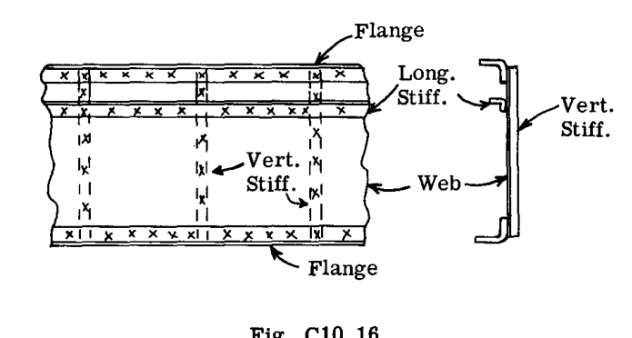

縦通材を使用した梁ウェブ

# パート2. その他のタイプの非座屈ウェブ梁

（W. F. McCOMBS 著）

## C10.16 その他のウェブ設計タイプ

ここで、パート1で議論されたウェブ設計が、軽量性を達成するために多数の部品（スチフナ）を必要としたことに注目すべきである。製造コストを低く抑えるためには、部品数を最小限に抑えなければならない。製造費用と重量ペナルティの間で、バランス、すなわち経済的な妥協点を見出さなければならない。これは、あらゆる航空機設計において、余分な重量1ポンドごとにある程度の「金銭的」ペナルティが割り当てられるため、到達可能である。正確な数値は、設計される航空機のタイプに依存する。したがって、部品を排除することは多少の重量ペナルティを招くかもしれないが、製造コストの節約がより大きければ、部品の削減は経済的である。

スチフナの費用を節約するために、航空機設計では3つのタイプの剪断抵抗性非座屈ウェブが頻繁に使用される。実際、ほとんどの場合、ウェブは独立したスチフナを持つウェブと同等かそれ以上に軽量である。しかし、梁に顕著な荷重が導入される場所にはスチフナを設けなければならないという一般的な制限がある。ウェブのタイプは以下の通りである。

1. 最小間隔で成形された垂直ビードを持つウェブ。
2. 様々な間隔で $45^{\circ}$ の成形フランジを持つ丸型の軽量化穴を有するウェブ。
3. 成形されたビード付きフランジを持つ丸型の軽量化穴を有し、穴の間に垂直な成形ビードを持つウェブ。

穴を持つウェブ（b）および（c）は、航空機内の多くの油圧・電気系統ラインや操縦系統のリンケージ用の組み込みアクセススペースも提供する。

## C10.17 ビード付きウェブ

図 C10.17 は、成形可能な最小間隔で「凸型」ビードが成形されたウェブを示している。ビードの断面は表 C10.5 に記載されている。

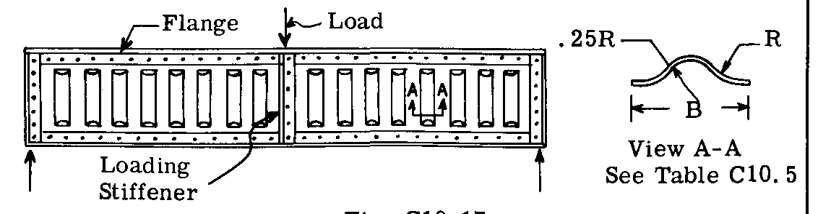

ビード付きウェブの例

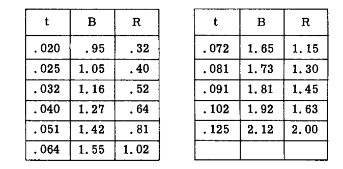

ビード断面寸法表

潰壊時の許容剪断流 $q$ （ポンド/インチ）は、図 C10.18 において実線で与えられている。点線は初期座屈の開始を示しているが、これは破壊（実線で示される）ではない。これは、独立したスチフナを持たないウェブシステムの中で最も強力なものである。破壊はビードが潰れたときに発生する。例題は後述の C10.19 で示される。荷重が導入される場所には、ビードの早期潰壊を防ぐために、（ビードに代わる）適切なスチフナを使用しなければならない。許容値は純粋剪断のみに対するものであり、垂直荷重は考慮されていない（第D3.7条参照）。

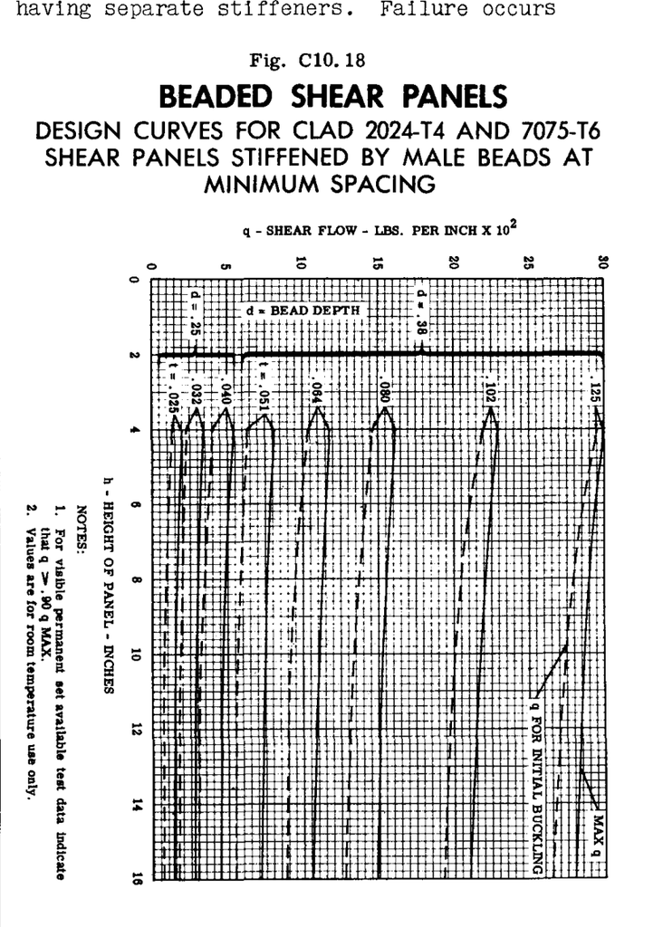

ビード付き剪断パネルの設計曲線

## C10.18 $45^{\circ}$ 成形フランジを持つ丸型軽量化穴を有するウェブ

これは、シンプルで容易に成形できるウェブである。図 C10.19 は、穴位置におけるウェブ断面を持つこのような梁を示している。穴とそのフランジの形状は、代表的な成形について表 C10.6 に示されている。

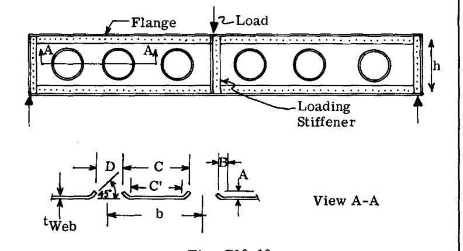

丸型軽量化穴を有するウェブの幾何形状

N.A.C.A.は、広範な試験プログラムから、このタイプの穴を持つウェブの許容剪断流（潰壊）を与える実験式を開発した。図 C10.19 を参照すると、許容剪断流は参考文献 (2) より以下の通りである。

$$q_{\text{ALL}} = k \, t \left[ f_{sh} \left(1 - \left(\frac{D}{h}\right)^2\right) + f_{sc} \sqrt[3]{\frac{D}{h}} \frac{C'}{b} \right] \tag{C10.18}$$

ここで、

$$k = 0.85 - 0.0006 \frac{h}{t}$$

$f_{sh}$ = 幅 $h$ 、厚さ $t$ の長い板の潰壊剪断応力（図 C10.20 より取得）。  
$f_{sc}$ = 幅 $c$ 、厚さ $t$ の長い板の潰壊剪断応力（図 C10.20 より取得）。  
$b$ = 穴の中心線間隔。  
$h$ = フランジからウェブのリベットまでのウェブの高さ。  
$C' = C - 2B$ 。ここで $B$ は代表的な穴について表 C10.6 に示されている。  
$C = b - D$

一般に、このタイプのウェブ設計では、極限荷重に耐えるように設計されたウェブは、降伏時に永久ひずみを示さない可能性が高い。

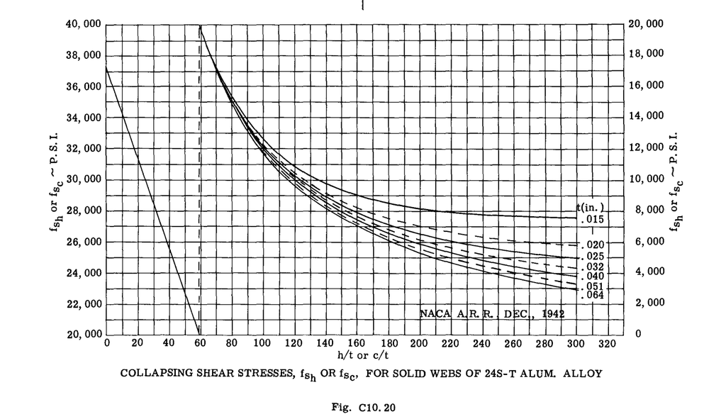

24S-Tアルミ合金ソリッドウェブの潰壊剪断応力

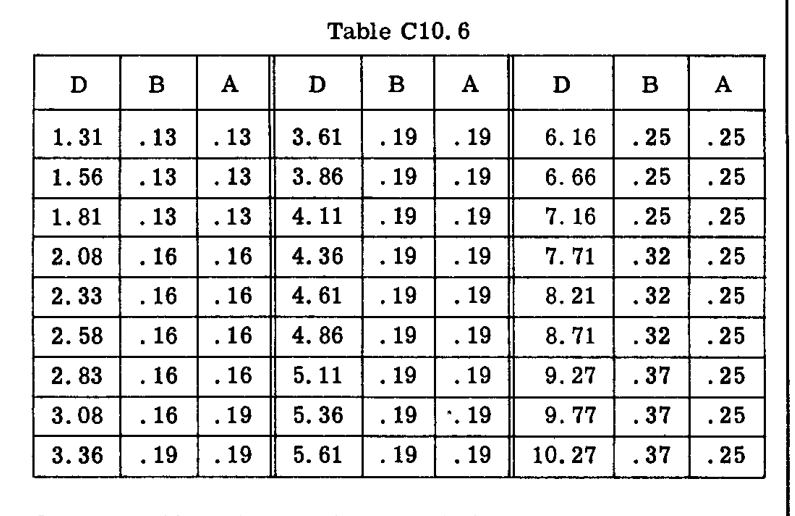

代表的な丸型穴の寸法表

実質的なネットセクション $C' \times t$ および $\frac{h}{h-D} \times t$ 上の降伏荷重における剪断応力が、ウェブ材料の降伏応力 $F_{sy}$ にほぼ等しい場合の荷重である。

一般に、式 (18) から、より広い間隔 $b$ を持つより大きな穴（約 $D \approx 0.8h$ ）が、与えられた剪断流 $q$ に対して最も軽いウェブを与えるが、剛性は当然低下することがわかる。

繰り返しになるが、式 (18) による許容値は純粋剪断のみに対するものであり、ウェブ上の垂直荷重は考慮されていない。したがって、梁に荷重が導入される場所、および丸型や楕円形のバルクヘッドのように梁に顕著な曲率がある領域には、スチフナを設けなければならない（第D3.8条参照）。一例が第C10.19条に示されている。

さらに、上記（潰壊）に加えて、極限荷重 $q \times h$ において $f_{\text{SNET}} < F_{su}$ であることを確認するために、穴を通る正味の剪断応力についてウェブを検討する必要がある。

このタイプのウェブ設計および試験データのより詳細な議論については、参考文献 (2) および (1) を参照されたい。式 (18) に頼ることなく設計に使用できるように、式 (18)、図 C10.18、および表 C10.6 から設計チャートを作成することができる。図 C10.21 は、 $D/h = 0.80$ および $D/h = 0.50$ の場合について、参考文献 (2) から引用したそのようなチャートを示している。

## C10.19 成形ビード付きフランジ軽量化穴および中間垂直凸ビードを持つウェブ

3番目のタイプのウェブは、ビード付きフランジを持つ丸型の穴と、穴の間に垂直な「凸」ビードを有している。このような梁を図 C10.22 に示す。垂直ビードは表 C10.5 に記載されている通りである。図示されているビード付きフランジは表 C10.7 に記載されている。 $\frac{\text{O.D.}}{h} \approx 0.6$ であり、穴の間隔が $h$ に等しい特定のケースでは、図 C10.23 に示す許容剪断流が適用される。

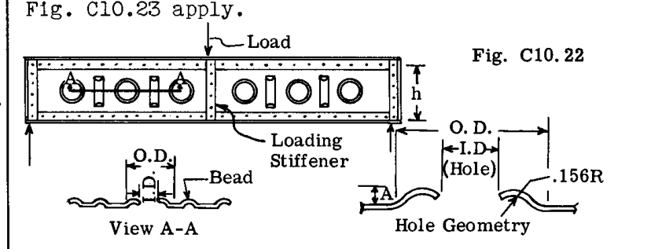

成形ビード付きフランジおよび中間ビードを持つウェブの幾何形状

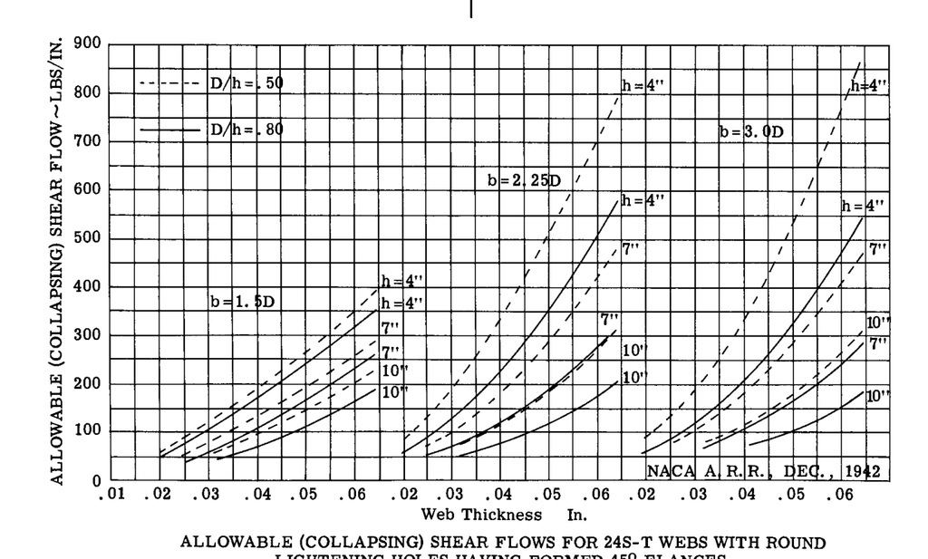

成形フランジ丸型穴を持つ24S-Tウェブの許容剪断流

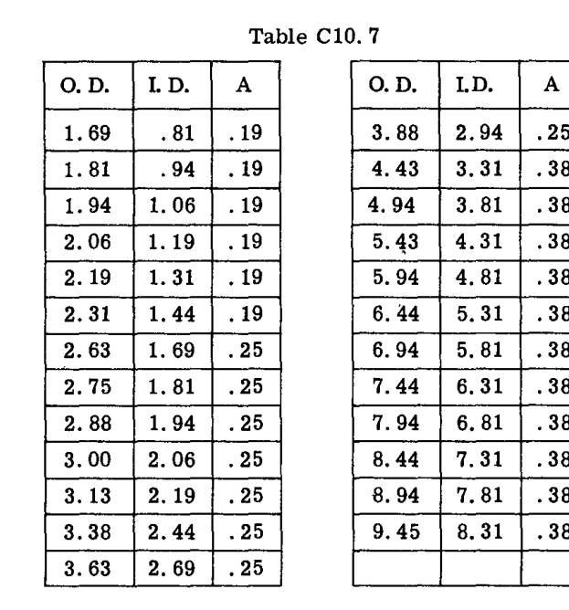

ビード付きフランジの寸法表

図 C10.23 の実線は、ウェブ高さ $h$ の関数として、ウェブの極限強度 $q$ を与えている。これはウェブの総潰壊強度を表している。点線は初期座屈が開始する剪断流 $q$ を示している。もし $\text{O.D.}$ が $0.6 \times h$ より大きい場合、または穴の間隔が狭められた場合、許容値は減少するが、他の幾何形状に関するデータは含まれていない。他のケースと同様に、データは純粋剪断のみに対するものであり、垂直荷重は考慮されていない。したがって、荷重スチフナを使用しなければならず（局所的に垂直ビードを置き換える）、第D3.8条を参照されたい。

もちろん、3つのタイプの成形ウェブすべてにおいて、少量の垂直荷重は許容され得るが、限界は定義されていない。代表的なケースとしては、スチフナなしでリブによって比較的軽い垂直空気荷重のみが分散される翼リブや胴体フレームがある。このような場合、設計者の判断や要素試験に基づいて、剪断荷重を超えるいくらかの追加の安全余裕が通常使用される。燃料セルを支持する梁のように大きな分布荷重が関与する場合、または梁の曲率が顕著である場合（第D3.7条参照）は、最も軽量な設計のためにスチフナを使用すべきである。

最後の注意点として、C10.17 や C10.19 のように成形ビードを持つウェブを使用する場合は常に、アセンブリが許す限り梁フランジに近づくのに十分な長さでビードを成形することが重要である。フランジから大きく離れて終わる短いビードは、図に示されている許容値によって示される強度を発揮しない。穴の上のフランジにウェブを取り付けるリベットも、局所的に高い「ネット」剪断に対応するために、より密に配置される必要がある。

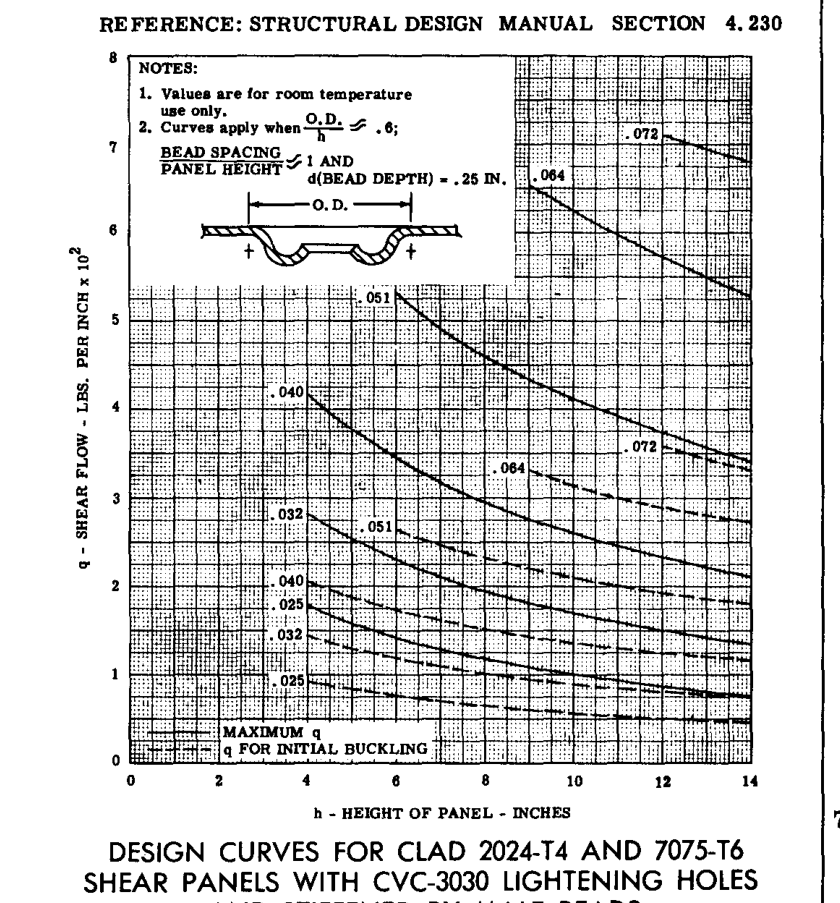

丸型穴および中間ビードを持つウェブの設計曲線

## C10.20 例題

図 C10.24 に示す梁について、以下の場合に必要なウェブゲージを決定せよ。

1. C10.17 のようなビード付きウェブ。
2. C10.18 のような $45^{\circ}$ フランジ付き穴ウェブ。
3. C10.19 のような中間ビード付きフランジ穴ウェブ。

図 C10.24 に示す梁は、本章のパート1の例題で使用された図 C10.14 に示す梁と同じ外形寸法と設計荷重システムを有している。これらの例題では、ウェブ設計を (a)、(b)、(c) の3つのバリエーションに置き換える。ウェブが梁の曲げ応力に抵抗する上で完全に有効であるとはみなせないため、フランジはパート1の例題で示された値よりもわずかに高い応力を受けることになる。同じ梁寸法と梁設計荷重を使用することで、様々なウェブ設計におけるウェブ重量の比較が可能となる。

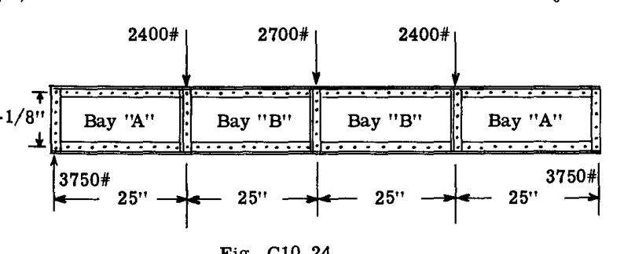

例題用の梁構成

簡易式を使用すると、ベイAおよびBにおける剪断流は以下の通りである。

$$q_A = \frac{V}{h} = \frac{3750}{7.125} = 526 \text{ lb./in.}$$

$$q_B = \frac{3750 - 2400}{7.125} = 189 \text{ lb./in.}$$

したがって、最も軽量にするためには、2つのウェブゲージを使用すべきであり、ベイ「B」にはより薄いウェブを使用し、これらは $2400 \text{ lb.}$ の荷重を導入する荷重スチフナ位置で接合することができる。

### a) ビード付きウェブのゲージ要件

$q = 526 \text{ lb./in.}$ および $h = 7.125$ インチで図 C10.18 に入ると、最小の許容ゲージは $0.051$ インチであることがわかる。したがって、ベイAのウェブは $0.051$ インチとすべきであり、図 C10.18 より $q_{\text{allow}} = 770 \text{ lb./in.}$ を得る。

$$\text{M.S.} = \frac{770}{526} - 1 = 0.46$$

ベイBのウェブについても同様に、 $q = 189 \text{ lb./in.}$ および $h = 7.125$ インチで入り、最小許容ゲージが $0.032$ インチであり、これが $q_{\text{ALL}} = 310 \text{ lb./in.}$ を持つことを見出す。したがって、ベイBについては、

$$\text{M.S.} = \frac{310}{189} - 1 = 0.64$$

### b) $45^{\circ}$ フランジ付き丸型軽量化穴

より大きな直径（およびより広い間隔）の穴の方が重量効率が良いため、 $D \approx 0.8h$ 、または表 C10.6 から $D = 5.61$ インチの穴を試みる。25インチのベイに2つの穴を配置すると、間隔 $b = 12.5$ インチとなる。その場合、C10.19 より、

$$C = b - D = 12.5 - 5.61 = 6.9$$

表 C10.6 より $B = 0.19$ である。  
$C' = C - 2B = 6.9 - 2(0.19) = 6.52$

ここで、例えばベイAに対して $t = 0.081$ インチとして、許容 $q$ 値を決定する。

$$\frac{h}{t} = \frac{7.125}{0.081} = 88$$

$$k = 0.85 - 0.0006(88) = 0.80$$

図 C10.20 より、 $\frac{h}{t} = 88$ および $\frac{c}{t} = 85$ に対して、

$$f_{sh} = 13,200$$

$$f_{sc} = 13,800$$

$$= 0.0648 \left[ 13,200(0.38) + 13,800(0.887)(0.521) \right]$$

$$= 573 \text{ lb./in.}$$

また、穴を通る任意の断面における正味の剪断応力は $F_{su}$ 未満でなければならない。穴を通る垂直断面を検討すると、以下を得る。

$$f_{s\text{NET}} = \frac{V}{(h - D)t} = \frac{526(7.125)}{(7.125 - 5.61)(0.081)} = \frac{3750}{0.122} = 30,500$$

したがって、

$$\text{M.S.}_{\text{COLL}} = \frac{573}{526} - 1 = 0.09$$

$$\text{M.S.}_{\text{NET}} = \frac{F_{su}}{f_{s\text{NET}}} - 1 = \frac{37,000}{30,500} - 1 = 0.21$$

上記の幾何形状を繰り返し、ベイ「B」（ $q = 189 \text{ lb./in.}$ ）に対して $t = 0.051$ を使用すると、以下を得る。

$$q_{\text{ALL}} = 0.77(0.051) \left[ 7900(0.38) + 8300(0.887) \right] (0.521) = 0.0393 [10,630](0.521) = 217 \text{ lb./in.}$$

$$\text{M.S.}_{\text{COLL}} = \frac{217}{189} - 1 = 0.15$$

および、

$$\text{M.S.}_{\text{NET}} = \frac{37,000}{17,400} - 1 = 1.12$$

読者は、より小さなサイズの穴や厚さについて上記を繰り返し、より軽量な配置（正味のウェブ重量）が得られるかどうかを確認することができる。例題のゲージが、 $0.081$ ウェブの場合に外挿された図 C10.21 のデータによって裏付けられていることがわかる。

### c) 中間垂直ビードを持つビード付きフランジ穴

これに関する幾何形状は、前述の通りである（ $\text{O.D.} \approx 0.6h$ および $b \approx h$ ）。

まずベイAのゲージを決定する。 $h = 7.125$ インチおよび $q = 526 \text{ lb./in.}$ で図 C10.23 に入ると、最も近い許容ゲージは $t = 0.064$ （実線）であり、以下を与える。

$$q_{\text{ALL}} = 700 \text{ lb./in.}$$

$$\text{M.S.} = \frac{700}{526} - 1 = 0.33$$

$q = 189$ および $h = 7.125$ インチを持つベイBについて繰り返すと、最も近い許容ゲージは $t = 0.032$ である。

$$q_{\text{ALL}} = 208 \text{ lb./in.}$$

$$\text{M.S.} = \frac{208}{189} - 1 = 0.10$$

実際には、 $\text{O.D.} = 4.43$ （表 C10.7 より）の穴を使用することができ、 $\frac{\text{O.D.}}{h} = \frac{4.43}{7.125} = 0.62$ は $0.6$ よりわずかに大きいが、上記の M.S. がゼロを十分に上回っているため使用可能である。

3つのタイプのウェブそれぞれの総重量の比較を表 C10.8 に示す。ここでは、ウェブ (b) には直径 $5.61$ インチの穴、ウェブ (c) には直径 $3.31$ インチ（表 C10.7 より）を使用し、アルミニウムの密度を $0.10 \text{ lb./in.}^3$ としている。

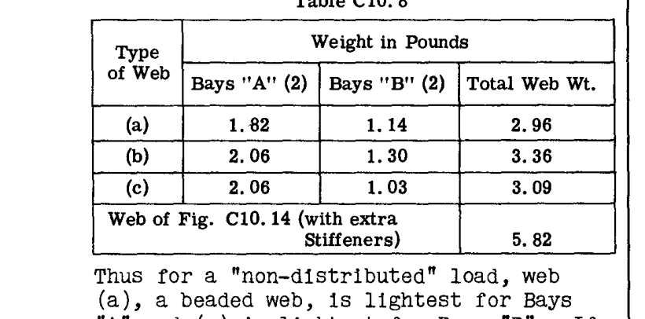

ウェブタイプの重量比較表

したがって、「非分布」荷重については、ビード付きウェブ (a) がベイ「A」に対して最も軽く、(c) がベイ「B」に対して最も軽い。もしライン用の「アクセス」が必要な場合は、ベイ「A」に対してタイプ (c) または (b) のウェブを使用すべきである。

曲げと剪断の組合せに対して初期座屈なしで設計されたウェブと垂直スチフナの重量は $5.82 \text{ lbs.}$ であり、他の設計よりもはるかに重い。

## 問題

1. 図 C10.25 は、翼梁の断面を示している。図 C10.4 に示されている押出 24ST 材の応力-ひずみ曲線を用いて、梁断面の極限耐力モーメントを計算せよ。上フランジの最外縁繊維における単位ひずみとして $0.008$ を使用せよ。その結果を、一般的な梁の公式 $M = f_b I / y$ によって与えられる耐力モーメントと比較せよ。

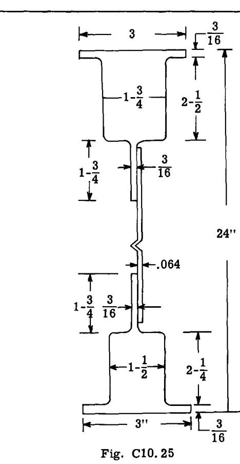

翼梁の断面図

2. 設計剪断荷重 $V = 3000 \text{ lb.}$ および曲げモーメント $50,000 \text{ in.lbs.}$ に対する、C10.13 の梁断面のウェブ突合せ継手を設計せよ。
3. 図 C10.26 は、図示のように配置された $2000 \text{ lb.}$ の設計荷重を支持する単純支持梁を示している。梁の断面を図 C10.27 に示す。ウェブに対する設計要件は、設計外力荷重下で初期座屈が発生しないことである。与えられた設計の強度を検証し、弱すぎるか強すぎる場合は修正（すなわち設計の改善）を行え。梁フランジは横方向の柱破壊に対して支持されていると仮定せよ。

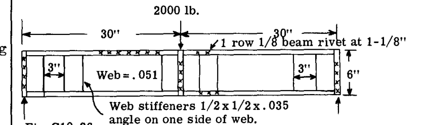

単純支持梁の荷重配置図

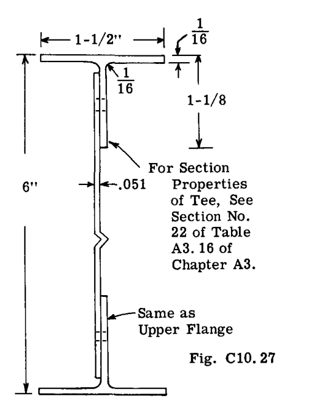

梁の断面詳細図

4. 問題 (3) の梁を、本章のパート2で提示された3つのタイプの補強ウェブを使用するように再設計せよ。ウェブ重量を問題 (3) で必要とされたウェブ重量と比較せよ。
5. 図 C10.28 は、図示の通り分布設計荷重を支持するテーパー付き片持ち梁の外形寸法を示している。ウェブは設計荷重下で座屈してはならない。すべての部品の寸法を示す、梁の完全な構造設計を行え。フランジには 7075-T6 押出材を、ウェブおよびウェブスチフナには 7075-T6 クラッド材を使用せよ。リベット設計を示せ。

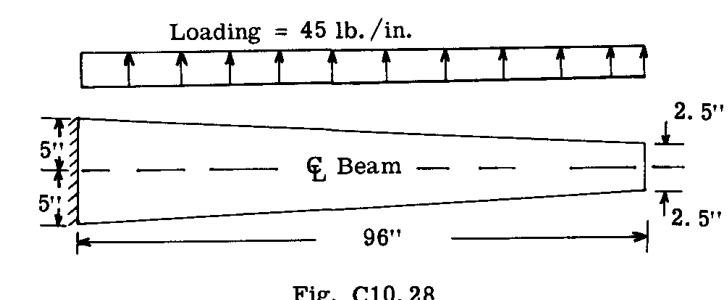

テーパー付き片持ち梁の外形寸法図

## 参考文献

1. Kuhn, Paul: - The Strength and Stiffness of Shear Webs With and Without Lightening Holes. NACA. ARR. June 1942.
2. Kuhn, Paul: - The Strength and Stiffness of Shear Webs with Round Lightening Holes Having $45^{\circ}$ Flanges. NACA. ARR. L-323 Dec. 1942.
3. Bleich, F.: - Buckling Strength of Metal Structures - Book - Publisher, McGraw-Hill pp. 418-24.